# Importação e diagnósticos iniciais

Gabriel R. R.

7/9/2020

# Considerações iniciais

Esse é um documento feito para ensinar e para reforçar conteúdos de manipulação de dados usando *dplyr*. Qualquer comentário, erro ou sugestão, é só falar comigo entrando em contato através de qualquer uma das opções listadas em *Contato*.

O script em R está disponível aqui: https://github.com/GabrielReisR/R/blob/master/estrutura%20de%20dados/import-e-diagn.R

Foram utilizados 10000 casos do dataset DASS42, retirado desse desafio do Kaggle: https://www.kaggle.com/lucasgreenwell/depression-anxiety-stress-scales-responses?select=data.csv

# Importando dados

A primeira tarefa quando se trata de manipular um banco de dados consiste na importação correta dos dados ao software de programação.

Vamos aprender a importar 3 tipos comuns de dados utilizando o R:

- *.sav*: dados do SPSS; vamos utilizar o pacote *haven*.
- *.xls/.xlsx*: tabelas do excel; vamos utilizar o pacote *readxl*.
- *.csv*: “comma-separated values”; pode ser importado com o pacote *readr* e com o pacote base do R.

## Importando *.sav*

Para importar um arquivo do SPSS (Statistical Package for the Social Sciences) vamos utilizar o pacote *haven*. Isso facilita a importação já que não precisaríamos fazer a conversão do arquivo .sav para um arquivo .csv, por exemplo.

Para começar, basta instalar *haven*.

```r
install.packages("haven", dependencies = T) # tenho como prática baixar pacotes associados sempre, por isso "dependencies = TRUE"
```

Para utilizar *haven*, basta ler o pacote e executar `read_sav("dataset")` para criar um objeto com o banco de dados.

Utilizarei um exemplo com um banco que pode ser encontrado aqui: https://github.com/GabrielReisR/R/blob/master/estrutura%20de%20dados/dados/dass42.sav

Você pode baixar o arquivo no link acima e tentar também :)

```r
library(haven) # leitura do haven

dass_sav <- read_sav("dass42.sav") # importando um .sav

dass_sav[1:10, ] # vamos ver os 10 primeiros casos
```

| Q1A | Q1I | Q1E | Q2A | Q2I | Q2E | Q3A | Q3I | Q3E | Q4A | Q4I | Q4E | Q5A | Q5I | Q5E | Q6A | Q6I | Q6E | Q7A | Q7I | Q7E | Q8A | Q8I | Q8E | Q9A | Q9I | Q9E | Q10A | Q10I | Q10E | … |
| --- | --- | --- | --- | --- | --- | --- | --- | --- | --- | --- | --- | --- | --- | --- | --- | --- | --- | --- | --- | --- | --- | --- | --- | --- | --- | --- | --- | --- | --- | --- |
| 4 | 28 | 3890 | 4 | 25 | 2122 | 2 | 16 | 1944 | 4 | 8 | 2044 | 4 | 34 | 2153 | 4 | 33 | 2416 | 4 | 10 | 2818 | 4 | 13 | 2259 | 2 | 21 | 5541 | 1 | 38 | 4441 | … |
| 4 | 2 | 8118 | 1 | 36 | 2890 | 2 | 35 | 4777 | 3 | 28 | 3090 | 4 | 10 | 5078 | 4 | 40 | 2790 | 3 | 18 | 3408 | 4 | 1 | 8342 | 3 | 37 | 916 | 2 | 32 | 1537 | … |
| 3 | 7 | 5784 | 1 | 33 | 4373 | 4 | 41 | 3242 | 1 | 13 | 6470 | 4 | 11 | 3927 | 3 | 9 | 3704 | 1 | 17 | 4550 | 3 | 5 | 3021 | 2 | 32 | 5864 | 4 | 21 | 3722 | … |
| 2 | 23 | 5081 | 3 | 11 | 6837 | 2 | 37 | 5521 | 1 | 27 | 4556 | 3 | 28 | 3269 | 3 | 26 | 3231 | 4 | 2 | 7138 | 2 | 19 | 3079 | 3 | 31 | 9650 | 3 | 17 | 4179 | … |
| 2 | 36 | 3215 | 2 | 13 | 7731 | 3 | 5 | 4156 | 4 | 10 | 2802 | 4 | 2 | 5628 | 2 | 9 | 6522 | 4 | 34 | 2374 | 4 | 11 | 3054 | 4 | 7 | 2975 | 3 | 14 | 3524 | … |
| 1 | 18 | 6116 | 1 | 28 | 3193 | 2 | 2 | 12542 | 1 | 8 | 6150 | 3 | 40 | 6428 | 1 | 4 | 17001 | 1 | 33 | 2944 | 3 | 7 | 8626 | 3 | 14 | 9639 | 2 | 20 | 6175 | … |
| 1 | 20 | 4325 | 1 | 34 | 4009 | 2 | 38 | 3604 | 3 | 40 | 4826 | 4 | 22 | 2842 | 1 | 42 | 2342 | 3 | 6 | 9018 | 3 | 31 | 3717 | 3 | 39 | 7023 | 4 | 35 | 3312 | … |
| 1 | 34 | 4796 | 1 | 9 | 2618 | 1 | 39 | 5823 | 1 | 12 | 6596 | 3 | 4 | 7635 | 2 | 31 | 7384 | 2 | 24 | 11570 | 1 | 33 | 2958 | 1 | 15 | 12300 | 1 | 5 | 3605 | … |
| 4 | 4 | 3470 | 4 | 14 | 2139 | 3 | 1 | 11043 | 4 | 20 | 1829 | 3 | 3 | 5847 | 4 | 7 | 3529 | 4 | 17 | 1855 | 4 | 29 | 3000 | 4 | 31 | 6066 | 3 | 21 | 2539 | … |
| 3 | 38 | 5187 | 2 | 28 | 2600 | 4 | 9 | 2015 | 1 | 7 | 3111 | 4 | 41 | 1712 | 4 | 22 | 1719 | 3 | 21 | 2049 | 4 | 11 | 2623 | 4 | 26 | 3853 | 4 | 12 | 1888 | … |

## Importando *.xls/xlsx*

Para importar um arquivo em Excel vamos utilizar o pacote *readxl*, que faz essa manipulação muito tranquilamente.

Para começar, basta instalar e ler o pacote *readxl*.

```r
install.packages("readxl", dependencies = T) # tenho como prática baixar pacotes associados sempre, por isso "dependencies = TRUE"
```

Para utilizar *readxl*, basta ler o pacote e executar `read_excel("dataset")` para criar um objeto com o banco de dados.

Utilizarei um exemplo com um banco que pode ser encontrado aqui: https://github.com/GabrielReisR/R/blob/master/estrutura%20de%20dados/dados/dass42.xlsx

Você pode baixar o arquivo no link acima e tentar também :)

```r
library(readxl) # leitura do readxl

dass_excel <- read_excel("dass42.xlsx") # importando um .xlsx

dass_excel[1:10, ] # vamos ver os 10 primeiros casos
```

| Q1A | Q1I | Q1E | Q2A | Q2I | Q2E | Q3A | Q3I | Q3E | Q4A | Q4I | Q4E | Q5A | Q5I | Q5E | Q6A | Q6I | Q6E | Q7A | Q7I | Q7E | Q8A | Q8I | Q8E | Q9A | Q9I | Q9E | Q10A | Q10I | Q10E | … |
| --- | --- | --- | --- | --- | --- | --- | --- | --- | --- | --- | --- | --- | --- | --- | --- | --- | --- | --- | --- | --- | --- | --- | --- | --- | --- | --- | --- | --- | --- | --- |
| 4 | 28 | 3890 | 4 | 25 | 2122 | 2 | 16 | 1944 | 4 | 8 | 2044 | 4 | 34 | 2153 | 4 | 33 | 2416 | 4 | 10 | 2818 | 4 | 13 | 2259 | 2 | 21 | 5541 | 1 | 38 | 4441 | … |
| 4 | 2 | 8118 | 1 | 36 | 2890 | 2 | 35 | 4777 | 3 | 28 | 3090 | 4 | 10 | 5078 | 4 | 40 | 2790 | 3 | 18 | 3408 | 4 | 1 | 8342 | 3 | 37 | 916 | 2 | 32 | 1537 | … |
| 3 | 7 | 5784 | 1 | 33 | 4373 | 4 | 41 | 3242 | 1 | 13 | 6470 | 4 | 11 | 3927 | 3 | 9 | 3704 | 1 | 17 | 4550 | 3 | 5 | 3021 | 2 | 32 | 5864 | 4 | 21 | 3722 | … |
| 2 | 23 | 5081 | 3 | 11 | 6837 | 2 | 37 | 5521 | 1 | 27 | 4556 | 3 | 28 | 3269 | 3 | 26 | 3231 | 4 | 2 | 7138 | 2 | 19 | 3079 | 3 | 31 | 9650 | 3 | 17 | 4179 | … |
| 2 | 36 | 3215 | 2 | 13 | 7731 | 3 | 5 | 4156 | 4 | 10 | 2802 | 4 | 2 | 5628 | 2 | 9 | 6522 | 4 | 34 | 2374 | 4 | 11 | 3054 | 4 | 7 | 2975 | 3 | 14 | 3524 | … |
| 1 | 18 | 6116 | 1 | 28 | 3193 | 2 | 2 | 12542 | 1 | 8 | 6150 | 3 | 40 | 6428 | 1 | 4 | 17001 | 1 | 33 | 2944 | 3 | 7 | 8626 | 3 | 14 | 9639 | 2 | 20 | 6175 | … |
| 1 | 20 | 4325 | 1 | 34 | 4009 | 2 | 38 | 3604 | 3 | 40 | 4826 | 4 | 22 | 2842 | 1 | 42 | 2342 | 3 | 6 | 9018 | 3 | 31 | 3717 | 3 | 39 | 7023 | 4 | 35 | 3312 | … |
| 1 | 34 | 4796 | 1 | 9 | 2618 | 1 | 39 | 5823 | 1 | 12 | 6596 | 3 | 4 | 7635 | 2 | 31 | 7384 | 2 | 24 | 11570 | 1 | 33 | 2958 | 1 | 15 | 12300 | 1 | 5 | 3605 | … |
| 4 | 4 | 3470 | 4 | 14 | 2139 | 3 | 1 | 11043 | 4 | 20 | 1829 | 3 | 3 | 5847 | 4 | 7 | 3529 | 4 | 17 | 1855 | 4 | 29 | 3000 | 4 | 31 | 6066 | 3 | 21 | 2539 | … |
| 3 | 38 | 5187 | 2 | 28 | 2600 | 4 | 9 | 2015 | 1 | 7 | 3111 | 4 | 41 | 1712 | 4 | 22 | 1719 | 3 | 21 | 2049 | 4 | 11 | 2623 | 4 | 26 | 3853 | 4 | 12 | 1888 | … |

## Importando *.csv*

Uma situação um pouco mais comum. O R já permite que façamos isso com a função `read.csv`. O pacote *readr* facilita o uso dessa função ao retirar um argumento do código base (`sep = ","`), então vamos apresentá-lo. Durante o restante, vamos utilizar apenas o de base (`read.csv`).

Para começar, basta instalar e ler o pacote *readr*. Ah, esse pacote é útil também para ler outros tipos de dados “retangulares” (como .tsv e .fwf).

```r
install.packages("readr", dependencies = T) # tenho como prática baixar pacotes associados sempre, por isso "dependencies = TRUE"
```

Feito a leitura do pacote, basta criar um objeto com o banco de dados, realizando a leitura com o código `read_csv("dataset")`. Não precisa de mais nenhum argumento. Para fazer isso, o arquivo precisa estar delimitado por vírgulas!

```r
library(readr) # lendo o pacote readr no R

dass_readr <- read_csv("https://raw.githubusercontent.com/GabrielReisR/R/master/estrutura%20de%20dados/dados/dass42.csv")

dass_readr[1:10, ] # vamos ver os 10 primeiros casos
```

| X1 | Q1A | Q1I | Q1E | Q2A | Q2I | Q2E | Q3A | Q3I | Q3E | Q4A | Q4I | Q4E | Q5A | Q5I | Q5E | Q6A | Q6I | Q6E | Q7A | Q7I | Q7E | Q8A | Q8I | Q8E | Q9A | Q9I | Q9E | Q10A | Q10I | … |
| --- | --- | --- | --- | --- | --- | --- | --- | --- | --- | --- | --- | --- | --- | --- | --- | --- | --- | --- | --- | --- | --- | --- | --- | --- | --- | --- | --- | --- | --- | --- |
| 15891 | 4 | 33 | 2583 | 2 | 23 | 2866 | 4 | 14 | 2140 | 1 | 15 | 2535 | 4 | 36 | 1508 | 4 | 2 | 5771 | 1 | 16 | 3131 | 2 | 18 | 3537 | 4 | 31 | 4086 | 4 | 12 | … |
| 26933 | 2 | 35 | 1370 | 2 | 29 | 1302 | 4 | 10 | 1230 | 3 | 26 | 3501 | 4 | 16 | 1033 | 2 | 34 | 1220 | 2 | 2 | 4546 | 4 | 27 | 1422 | 3 | 7 | 4181 | 4 | 30 | … |
| 33288 | 2 | 40 | 5203 | 4 | 19 | 1442 | 3 | 27 | 6936 | 3 | 21 | 5819 | 4 | 41 | 3402 | 4 | 14 | 2518 | 3 | 28 | 4101 | 4 | 29 | 3622 | 2 | 2 | 15936 | 3 | 37 | … |
| 19937 | 1 | 6 | 9924 | 1 | 12 | 4685 | 2 | 17 | 8358 | 1 | 1 | 24825 | 1 | 41 | 8463 | 1 | 32 | 8018 | 1 | 21 | 5065 | 1 | 39 | 5771 | 1 | 23 | 6849 | 2 | 27 | … |
| 15360 | 2 | 32 | 4529 | 4 | 25 | 4217 | 2 | 17 | 4537 | 1 | 9 | 3379 | 2 | 10 | 8471 | 4 | 22 | 8029 | 1 | 8 | 3306 | 4 | 26 | 5191 | 4 | 18 | 6997 | 2 | 27 | … |
| 33969 | 1 | 16 | 2387 | 1 | 7 | 2007 | 1 | 31 | 1450 | 1 | 42 | 2504 | 1 | 5 | 4358 | 1 | 32 | 2418 | 1 | 38 | 565 | 1 | 36 | 1373 | 1 | 37 | 993 | 1 | 39 | … |
| 9541 | 3 | 2 | 15583 | 4 | 19 | 2714 | 2 | 36 | 4817 | 4 | 10 | 2428 | 3 | 41 | 5802 | 4 | 9 | 2363 | 2 | 12 | 6314 | 4 | 24 | 1961 | 2 | 42 | 7959 | 2 | 14 | … |
| 25079 | 2 | 18 | 1721 | 3 | 39 | 3711 | 3 | 42 | 1759 | 1 | 32 | 2968 | 1 | 29 | 2667 | 3 | 21 | 2251 | 1 | 38 | 3256 | 2 | 16 | 1661 | 2 | 12 | 5282 | 2 | 22 | … |
| 19962 | 3 | 29 | 5163 | 3 | 8 | 4160 | 2 | 37 | 10475 | 2 | 9 | 5134 | 4 | 33 | 3548 | 4 | 7 | 4502 | 2 | 23 | 4215 | 1 | 22 | 3827 | 3 | 42 | 8550 | 3 | 30 | … |
| 29906 | 2 | 36 | 1893 | 2 | 34 | 1665 | 3 | 4 | 2713 | 1 | 10 | 3081 | 1 | 15 | 2979 | 2 | 8 | 3194 | 1 | 31 | 1907 | 2 | 28 | 2321 | 3 | 5 | 3223 | 1 | 22 | … |

Para ler o .csv com a função base do R (que é muito simples de usar), vamos utilizar o mesmo banco de dados como exemplo: https://github.com/GabrielReisR/R/blob/master/Import%20e%20diagn/Dados/dass42.csv

```r
dass_base <- read.csv("https://raw.githubusercontent.com/GabrielReisR/R/master/estrutura%20de%20dados/dados/dass42.csv", sep = ",")

dass_base[1:10, ] # vamos ver os 10 primeiros casos
```

|  | X | Q1A | Q1I | Q1E | Q2A | Q2I | Q2E | Q3A | Q3I | Q3E | Q4A | Q4I | Q4E | Q5A | Q5I | Q5E | Q6A | Q6I | Q6E | Q7A | Q7I | Q7E | Q8A | Q8I | Q8E | Q9A | Q9I | Q9E | Q10A | … |
| --- | --- | --- | --- | --- | --- | --- | --- | --- | --- | --- | --- | --- | --- | --- | --- | --- | --- | --- | --- | --- | --- | --- | --- | --- | --- | --- | --- | --- | --- | --- |
| 1 | 15891 | 4 | 33 | 2583 | 2 | 23 | 2866 | 4 | 14 | 2140 | 1 | 15 | 2535 | 4 | 36 | 1508 | 4 | 2 | 5771 | 1 | 16 | 3131 | 2 | 18 | 3537 | 4 | 31 | 4086 | 4 | … |
| 2 | 26933 | 2 | 35 | 1370 | 2 | 29 | 1302 | 4 | 10 | 1230 | 3 | 26 | 3501 | 4 | 16 | 1033 | 2 | 34 | 1220 | 2 | 2 | 4546 | 4 | 27 | 1422 | 3 | 7 | 4181 | 4 | … |
| 3 | 33288 | 2 | 40 | 5203 | 4 | 19 | 1442 | 3 | 27 | 6936 | 3 | 21 | 5819 | 4 | 41 | 3402 | 4 | 14 | 2518 | 3 | 28 | 4101 | 4 | 29 | 3622 | 2 | 2 | 15936 | 3 | … |
| 4 | 19937 | 1 | 6 | 9924 | 1 | 12 | 4685 | 2 | 17 | 8358 | 1 | 1 | 24825 | 1 | 41 | 8463 | 1 | 32 | 8018 | 1 | 21 | 5065 | 1 | 39 | 5771 | 1 | 23 | 6849 | 2 | … |
| 5 | 15360 | 2 | 32 | 4529 | 4 | 25 | 4217 | 2 | 17 | 4537 | 1 | 9 | 3379 | 2 | 10 | 8471 | 4 | 22 | 8029 | 1 | 8 | 3306 | 4 | 26 | 5191 | 4 | 18 | 6997 | 2 | … |
| 6 | 33969 | 1 | 16 | 2387 | 1 | 7 | 2007 | 1 | 31 | 1450 | 1 | 42 | 2504 | 1 | 5 | 4358 | 1 | 32 | 2418 | 1 | 38 | 565 | 1 | 36 | 1373 | 1 | 37 | 993 | 1 | … |
| 7 | 9541 | 3 | 2 | 15583 | 4 | 19 | 2714 | 2 | 36 | 4817 | 4 | 10 | 2428 | 3 | 41 | 5802 | 4 | 9 | 2363 | 2 | 12 | 6314 | 4 | 24 | 1961 | 2 | 42 | 7959 | 2 | … |
| 8 | 25079 | 2 | 18 | 1721 | 3 | 39 | 3711 | 3 | 42 | 1759 | 1 | 32 | 2968 | 1 | 29 | 2667 | 3 | 21 | 2251 | 1 | 38 | 3256 | 2 | 16 | 1661 | 2 | 12 | 5282 | 2 | … |
| 9 | 19962 | 3 | 29 | 5163 | 3 | 8 | 4160 | 2 | 37 | 10475 | 2 | 9 | 5134 | 4 | 33 | 3548 | 4 | 7 | 4502 | 2 | 23 | 4215 | 1 | 22 | 3827 | 3 | 42 | 8550 | 3 | … |
| 10 | 29906 | 2 | 36 | 1893 | 2 | 34 | 1665 | 3 | 4 | 2713 | 1 | 10 | 3081 | 1 | 15 | 2979 | 2 | 8 | 3194 | 1 | 31 | 1907 | 2 | 28 | 2321 | 3 | 5 | 3223 | 1 | … |

O argumento `sep = ","` informa à função `read.csv` que o arquivo está separado por vírgula. Para entender a separação do arquivo, basta visualizá-lo.

# Explorando o banco de dados

Assim que carregado, um banco de dados precisa ser entendido e visualizado. Suas limitações acessadas e modificações feitas de acordo com o objetivo da análise. **Nesse momento, vamos apenas visualizar as respostas do banco de dados e acessar os missings dele.**

Vamos utilizar o banco DASS42 que:

Vamos começar carregando nosso banco de dados. Uma vez como um objeto nomeado de *dass*.

```r
dass <- read.csv("https://raw.githubusercontent.com/GabrielReisR/R/master/estrutura%20de%20dados/dados/dass42.csv", sep = ",")
```

## Funções úteis

Para entender o banco, podemos utilizar:

- `View()`: abre uma janela para visualização dos dados.
- `names()`: apresenta os nomes de todas as colunas do dataset.
- `str()`: apresenta a estrutura do dataset.
- `head()`: primeiros casos do banco de dados.
- `tail()`: últimos casos do banco de dados.
- `glimpse()`: uma visualização limitada de algumas variáveis e alguns casos.
- `skim()`: análises descritivas iniciais (incluindo mini-histogramas) de variáveis númericas.

Vamos ver o que cada uma das outras funções faz.

`View()` abre uma janela dentro do próprio RStudio para visualização dos dados do banco.

```r
View(dass) # útil para explorar todos casos e/ou todas variáveis
```

Fazendo isso, abre-se uma janela no RStudio como essa:

[figure not shown]

`names()`, que retorna o nome das colunas do banco.

```r
names(dass) # útil para uma lida rápida nas variáveis contempladas pelo banco
```

```
##   [1] "X"                     "Q1A"                   "Q1I"
##   [4] "Q1E"                   "Q2A"                   "Q2I"
##   [7] "Q2E"                   "Q3A"                   "Q3I"
##  [10] "Q3E"                   "Q4A"                   "Q4I"
##  [13] "Q4E"                   "Q5A"                   "Q5I"
##  [16] "Q5E"                   "Q6A"                   "Q6I"
##  [19] "Q6E"                   "Q7A"                   "Q7I"
##  [22] "Q7E"                   "Q8A"                   "Q8I"
##  [25] "Q8E"                   "Q9A"                   "Q9I"
##  [28] "Q9E"                   "Q10A"                  "Q10I"
##  [31] "Q10E"                  "Q11A"                  "Q11I"
##  [34] "Q11E"                  "Q12A"                  "Q12I"
##  [37] "Q12E"                  "Q13A"                  "Q13I"
##  [40] "Q13E"                  "Q14A"                  "Q14I"
##  [43] "Q14E"                  "Q15A"                  "Q15I"
```

[output cut: 43 more lines]

`str()` fornece uma lida rápida das variáveis e dos valores delas.

```r
str(dass) # entender a estrutura do nosso objeto
```

```
## 'data.frame':    10000 obs. of  173 variables:
##  $ X                    : num  15891 26933 33288 19937 15360 ...
##  $ Q1A                  : int  4 2 2 1 2 1 3 2 3 2 ...
##  $ Q1I                  : int  33 35 40 6 32 16 2 18 29 36 ...
##  $ Q1E                  : int  2583 1370 5203 9924 4529 2387 15583 1721 5163 1893 ...
##  $ Q2A                  : int  2 2 4 1 4 1 4 3 3 2 ...
##  $ Q2I                  : int  23 29 19 12 25 7 19 39 8 34 ...
##  $ Q2E                  : int  2866 1302 1442 4685 4217 2007 2714 3711 4160 1665 ...
##  $ Q3A                  : int  4 4 3 2 2 1 2 3 2 3 ...
##  $ Q3I                  : int  14 10 27 17 17 31 36 42 37 4 ...
##  $ Q3E                  : int  2140 1230 6936 8358 4537 1450 4817 1759 10475 2713 ...
##  $ Q4A                  : int  1 3 3 1 1 1 4 1 2 1 ...
##  $ Q4I                  : int  15 26 21 1 9 42 10 32 9 10 ...
##  $ Q4E                  : int  2535 3501 5819 24825 3379 2504 2428 2968 5134 3081 ...
##  $ Q5A                  : int  4 4 4 1 2 1 3 1 4 1 ...
```

[output cut: 86 more lines]

`head()` resulta nos valores dos primeiros casos. Podemos especificar quantos casos queremos com `n =`.

```r
head(dass, n = 5) # útil para entender o tipo de resposta de cada variável em alguns casos
```

|  | X | Q1A | Q1I | Q1E | Q2A | Q2I | Q2E | Q3A | Q3I | Q3E | Q4A | Q4I | Q4E | Q5A | Q5I | Q5E | Q6A | Q6I | Q6E | Q7A | Q7I | Q7E | Q8A | Q8I | Q8E | Q9A | Q9I | Q9E | Q10A | … |
| --- | --- | --- | --- | --- | --- | --- | --- | --- | --- | --- | --- | --- | --- | --- | --- | --- | --- | --- | --- | --- | --- | --- | --- | --- | --- | --- | --- | --- | --- | --- |
| 1 | 15891 | 4 | 33 | 2583 | 2 | 23 | 2866 | 4 | 14 | 2140 | 1 | 15 | 2535 | 4 | 36 | 1508 | 4 | 2 | 5771 | 1 | 16 | 3131 | 2 | 18 | 3537 | 4 | 31 | 4086 | 4 | … |
| 2 | 26933 | 2 | 35 | 1370 | 2 | 29 | 1302 | 4 | 10 | 1230 | 3 | 26 | 3501 | 4 | 16 | 1033 | 2 | 34 | 1220 | 2 | 2 | 4546 | 4 | 27 | 1422 | 3 | 7 | 4181 | 4 | … |
| 3 | 33288 | 2 | 40 | 5203 | 4 | 19 | 1442 | 3 | 27 | 6936 | 3 | 21 | 5819 | 4 | 41 | 3402 | 4 | 14 | 2518 | 3 | 28 | 4101 | 4 | 29 | 3622 | 2 | 2 | 15936 | 3 | … |
| 4 | 19937 | 1 | 6 | 9924 | 1 | 12 | 4685 | 2 | 17 | 8358 | 1 | 1 | 24825 | 1 | 41 | 8463 | 1 | 32 | 8018 | 1 | 21 | 5065 | 1 | 39 | 5771 | 1 | 23 | 6849 | 2 | … |
| 5 | 15360 | 2 | 32 | 4529 | 4 | 25 | 4217 | 2 | 17 | 4537 | 1 | 9 | 3379 | 2 | 10 | 8471 | 4 | 22 | 8029 | 1 | 8 | 3306 | 4 | 26 | 5191 | 4 | 18 | 6997 | 2 | … |

`tail()` resulta nos valores dos últimos casos. Podemos especificar quantos casos queremos com `n =`.

```r
tail(dass, n = 5) # útil para entender o tipo de resposta de cada variável em alguns casos
```

|  | X | Q1A | Q1I | Q1E | Q2A | Q2I | Q2E | Q3A | Q3I | Q3E | Q4A | Q4I | Q4E | Q5A | Q5I | Q5E | Q6A | Q6I | Q6E | Q7A | Q7I | Q7E | Q8A | Q8I | Q8E | Q9A | Q9I | Q9E | Q10A | … |
| --- | --- | --- | --- | --- | --- | --- | --- | --- | --- | --- | --- | --- | --- | --- | --- | --- | --- | --- | --- | --- | --- | --- | --- | --- | --- | --- | --- | --- | --- | --- |
| 9996 | 12080.0 | 4 | 11 | 2385 | 4 | 10 | 1999 | 2 | 26 | 2704 | 3 | 39 | 3320 | 3 | 18 | 2800 | 3 | 31 | 1959 | 4 | 35 | 2528 | 4 | 13 | 2199 | 4 | 24 | 2559 | 4 | … |
| 9997 | 3881.0 | 1 | 24 | 2196 | 1 | 28 | 2093 | 4 | 18 | 5543 | 1 | 14 | 1633 | 1 | 8 | 4273 | 2 | 17 | 2813 | 1 | 25 | 1750 | 1 | 35 | 2073 | 1 | 7 | 3300 | 1 | … |
| 9998 | 7655.0 | 4 | 21 | 8766 | 2 | 34 | 25191 | 4 | 40 | 8839 | 4 | 35 | 9081 | 3 | 24 | 27035 | 4 | 14 | 21257 | 3 | 29 | 29084 | 3 | 28 | 4042 | 3 | 19 | 2531 | 4 | … |
| 9999 | 32995.1 | 3 | 18 | 2483 | 2 | 5 | 4138 | 2 | 31 | 2975 | 1 | 26 | 2923 | 3 | 1 | 15037 | 2 | 23 | 1960 | 2 | 22 | 3940 | 2 | 34 | 2632 | 3 | 3 | 25933 | 3 | … |
| 10000 | 23849.0 | 4 | 15 | 439 | 4 | 23 | 303 | 3 | 18 | 472 | 3 | 36 | 329 | 4 | 2 | 23088 | 4 | 38 | 208 | 3 | 34 | 327 | 4 | 10 | 325 | 3 | 12 | 440 | 4 | … |

Vimos que `head()` e `tail()` proporcionam a leitura dos casos considerando **todas as colunas do dataframe**. Isso dificulta muito a compreensão do banco, pois precisamos ir de variável em variável para ter um resumo dos casos.

## glimpse() e skim()

Assim como em `str()`, vamos resumir os casos com mais duas funções. Para isso, vamos instalar dois pacotes que vão nos auxiliar: o pacote *dplyr* e o pacote *skimr*.

```r
install.packages("dplyr", dependencies = T) # manipulação de banco de dados
```

Agora, vamos ver a função `glimpse()` do dplyr em ação.

```r
library(dplyr) # leitura do pacote dplyr
glimpse(dass)
```

```
## Rows: 10,000
## Columns: 173
## $ X                     <dbl> 15891, 26933, 33288, 19937, 15360, 33969, 954...
## $ Q1A                   <int> 4, 2, 2, 1, 2, 1, 3, 2, 3, 2, 2, 2, 3, 3, 3, ...
## $ Q1I                   <int> 33, 35, 40, 6, 32, 16, 2, 18, 29, 36, 11, 3, ...
## $ Q1E                   <int> 2583, 1370, 5203, 9924, 4529, 2387, 15583, 17...
## $ Q2A                   <int> 2, 2, 4, 1, 4, 1, 4, 3, 3, 2, 3, 2, 3, 1, 1, ...
## $ Q2I                   <int> 23, 29, 19, 12, 25, 7, 19, 39, 8, 34, 5, 29, ...
## $ Q2E                   <int> 2866, 1302, 1442, 4685, 4217, 2007, 2714, 371...
## $ Q3A                   <int> 4, 4, 3, 2, 2, 1, 2, 3, 2, 3, 1, 3, 2, 4, 2, ...
## $ Q3I                   <int> 14, 10, 27, 17, 17, 31, 36, 42, 37, 4, 17, 2,...
## $ Q3E                   <int> 2140, 1230, 6936, 8358, 4537, 1450, 4817, 175...
## $ Q4A                   <int> 1, 3, 3, 1, 1, 1, 4, 1, 2, 1, 1, 3, 3, 1, 1, ...
## $ Q4I                   <int> 15, 26, 21, 1, 9, 42, 10, 32, 9, 10, 16, 13, ...
## $ Q4E                   <int> 2535, 3501, 5819, 24825, 3379, 2504, 2428, 29...
```

[output cut: 160 more lines]

Uma visão bem mais completa das variáveis, sem dúvida. É bastante semelhante à função `str()` e produz um resultado mais organizado. Conseguimos entender tanto os primeiros casos quando o tipo de dados contido em cada coluna e seus respectivos nomes.

Agora vamos ver como funciona com a função `skim()`.

```r
install.packages("skimr", dependencies = T) # compreensão rápida de banco de dados
```

Depois de instalar o pacote, basta lê-lo e executar `skim()`

```r
library(skimr)
skim(dass)
```

Data summary

| Name | dass |
| --- | --- |
| Number of rows | 10000 |
| Number of columns | 173 |
| _______________________ |  |
| Column type frequency: |  |
| character | 2 |
| numeric | 171 |
| ________________________ |  |
| Group variables | None |

**Variable type: character**

| skim_variable | n_missing | complete_rate | min | max | empty | n_unique | whitespace |
| --- | --- | --- | --- | --- | --- | --- | --- |
| country | 0 | 1 | 2 | 4 | 0 | 114 | 0 |
| major | 0 | 1 | 0 | 45 | 2855 | 1899 | 10 |

**Variable type: numeric**

| skim_variable | n_missing | complete_rate | mean | sd | p0 | p25 | p50 | p75 | p100 | hist |
| --- | --- | --- | --- | --- | --- | --- | --- | --- | --- | --- |
| X | 0 | 1 | 19927.52 | 11482.57 | 1 | 9981.08 | 19869.05 | 29890.25 | 39774 | ▇▇▇▇▇ |
| Q1A | 0 | 1 | 2.62 | 1.03 | 1 | 2.00 | 3.00 | 4.00 | 4 | ▃▇▁▆▆ |
| Q1I | 0 | 1 | 21.51 | 12.08 | 1 | 11.00 | 21.00 | 32.00 | 42 | ▇▇▇▇▇ |
| Q1E | 0 | 1 | 5777.53 | 16817.41 | 181 | 2631.00 | 3561.00 | 5241.00 | 1101981 | ▇▁▁▁▁ |
| Q2A | 0 | 1 | 2.17 | 1.11 | 1 | 1.00 | 2.00 | 3.00 | 4 | ▇▆▁▃▅ |
| Q2I | 0 | 1 | 21.16 | 12.16 | 1 | 11.00 | 21.00 | 32.00 | 42 | ▇▇▇▇▇ |
| Q2E | 0 | 1 | 4982.04 | 8731.64 | 185 | 2469.75 | 3497.00 | 5167.00 | 585169 | ▇▁▁▁▁ |
| Q3A | 0 | 1 | 2.23 | 1.04 | 1 | 1.00 | 2.00 | 3.00 | 4 | ▆▇▁▅▃ |
| Q3I | 0 | 1 | 21.56 | 12.16 | 1 | 11.00 | 22.00 | 32.00 | 42 | ▇▇▇▇▇ |
| Q3E | 0 | 1 | 8818.11 | 286169.67 | -10814 | 2833.00 | 3887.50 | 5801.75 | 28582689 | ▇▁▁▁▁ |
| Q4A | 0 | 1 | 1.96 | 1.04 | 1 | 1.00 | 2.00 | 3.00 | 4 | ▇▅▁▃▂ |
| Q4I | 0 | 1 | 21.49 | 12.24 | 1 | 11.00 | 22.00 | 32.00 | 42 | ▇▇▆▇▇ |
| Q4E | 0 | 1 | 7207.34 | 76210.90 | 182 | 2916.00 | 4233.00 | 6232.75 | 7328321 | ▇▁▁▁▁ |
| Q5A | 0 | 1 | 2.52 | 1.07 | 1 | 2.00 | 2.00 | 3.00 | 4 | ▅▇▁▆▆ |
| Q5I | 0 | 1 | 21.56 | 12.14 | 1 | 11.00 | 22.00 | 32.00 | 42 | ▇▇▇▇▇ |
| Q5E | 0 | 1 | 5355.65 | 24366.91 | 186 | 2308.50 | 3216.00 | 4798.25 | 1698681 | ▇▁▁▁▁ |
| Q6A | 0 | 1 | 2.54 | 1.05 | 1 | 2.00 | 2.00 | 3.00 | 4 | ▅▇▁▆▆ |
| Q6I | 0 | 1 | 21.58 | 12.11 | 1 | 11.00 | 22.00 | 32.00 | 42 | ▇▇▇▇▇ |
| Q6E | 0 | 1 | 5107.78 | 14452.76 | 186 | 2366.00 | 3239.00 | 4816.00 | 930357 | ▇▁▁▁▁ |
| Q7A | 0 | 1 | 1.94 | 1.04 | 1 | 1.00 | 2.00 | 3.00 | 4 | ▇▅▁▂▂ |
| Q7I | 0 | 1 | 21.68 | 12.15 | 1 | 11.00 | 22.00 | 32.00 | 42 | ▇▆▇▇▇ |
| Q7E | 0 | 1 | 12633.29 | 741272.06 | 183 | 2619.75 | 3688.50 | 5316.00 | 74124488 | ▇▁▁▁▁ |
| Q8A | 0 | 1 | 2.48 | 1.05 | 1 | 2.00 | 2.00 | 3.00 | 4 | ▅▇▁▆▅ |
| Q8I | 0 | 1 | 21.42 | 12.08 | 1 | 11.00 | 21.00 | 32.00 | 42 | ▇▇▇▇▇ |
| Q8E | 0 | 1 | 4893.67 | 32819.01 | 191 | 2099.75 | 2848.00 | 4250.00 | 2103626 | ▇▁▁▁▁ |
| Q9A | 0 | 1 | 2.67 | 1.07 | 1 | 2.00 | 3.00 | 4.00 | 4 | ▅▇▁▆▇ |
| Q9I | 0 | 1 | 21.41 | 12.05 | 1 | 11.00 | 22.00 | 32.00 | 42 | ▇▇▇▇▇ |
| Q9E | 0 | 1 | 39132.50 | 2799416.35 | 183 | 4197.00 | 6052.00 | 9198.25 | 279772213 | ▇▁▁▁▁ |
| Q10A | 0 | 1 | 2.45 | 1.14 | 1 | 1.00 | 2.00 | 4.00 | 4 | ▇▇▁▆▇ |
| Q10I | 0 | 1 | 21.49 | 12.21 | 1 | 11.00 | 21.00 | 32.00 | 42 | ▇▇▆▇▇ |

[output cut: 141 more lines]

`skim()` vai um passo além e fornece análises descritivas iniciais, junto com mini-histogramas, para todas as variáveis numéricas. Certamente ajuda na detecção de missing values.

## Visualizando missings com Amelia

Falando em missing values, o pacote *Amelia* auxilia na compreensão de onde os missing values da amostra estão com a função `missmap()`.

```r
install.packages("Amelia", dependencies = T) # diagnóstico e manipulação de missings
```

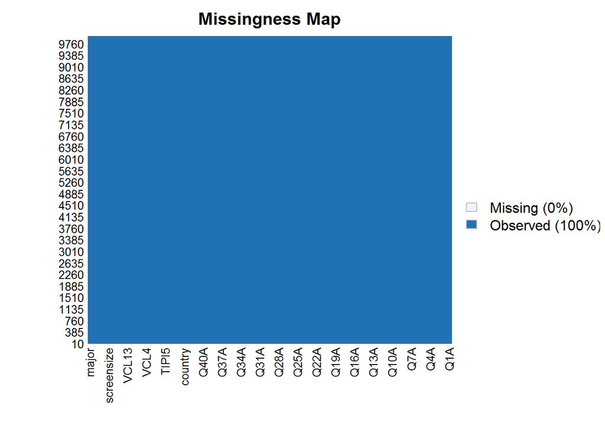

```r
library(Amelia) # leitura do pacote Amelia
missmap(dass)
```

Podemos perceber que não há nenhum missing computado nesse banco! Que maravilha :)

Por enquanto é isso! :)

# Mais informações

Introdução ao R: https://rpubs.com/reisrgabriel/introaor

Manipulando com dplyr - Parte 1: select() e mutate(): https://rpubs.com/reisrgabriel/dplyrPt1

Manipulando com dplyr - Parte 2: bind() e join(): https://rpubs.com/reisrgabriel/dplyrPt2

# Contato

Email: reisrgabriel@gmail.com

GitHub : https://github.com/GabrielReisR

LinkedIn: https://www.linkedin.com/in/gabrielreisrodrigues/